# class11

## Workspace Setup

```r
#Get and load DESeq2 from Bioconductor for Data
#BiocManager::install("DESeq2")

library(BiocManager)
library(DESeq2)
#Import countData and colData
counts <- read.csv("airway_scaledcounts.csv", row.names=1)
metadata <- read.csv("airway_metadata.csv")

head(counts)
```

|  | SRR1039508 | SRR1039509 | SRR1039512 | SRR1039513 | SRR1039516 | SRR1039517 | SRR1039520 | SRR1039521 |
| --- | --- | --- | --- | --- | --- | --- | --- | --- |
| ENSG00000000003 | 723 | 486 | 904 | 445 | 1170 | 1097 | 806 | 604 |
| ENSG00000000005 | 0 | 0 | 0 | 0 | 0 | 0 | 0 | 0 |
| ENSG00000000419 | 467 | 523 | 616 | 371 | 582 | 781 | 417 | 509 |
| ENSG00000000457 | 347 | 258 | 364 | 237 | 318 | 447 | 330 | 324 |
| ENSG00000000460 | 96 | 81 | 73 | 66 | 118 | 94 | 102 | 74 |
| ENSG00000000938 | 0 | 0 | 1 | 0 | 2 | 0 | 0 | 0 |

```r
head(metadata)
```

|  | id | dex | celltype | geo_id |
| --- | --- | --- | --- | --- |
| 1 | SRR1039508 | control | N61311 | GSM1275862 |
| 2 | SRR1039509 | treated | N61311 | GSM1275863 |
| 3 | SRR1039512 | control | N052611 | GSM1275866 |
| 4 | SRR1039513 | treated | N052611 | GSM1275867 |
| 5 | SRR1039516 | control | N080611 | GSM1275870 |
| 6 | SRR1039517 | treated | N080611 | GSM1275871 |

```r
#Double check that the columns of the countdata match the rows of the coldata; 'all()' funciton makes sure that all the values come back TRUE
#'all()': all true -> TRUE, any false -> FALSE, all false -> FALSE
all(metadata$id == colnames(counts))
```

```
## [1] TRUE
```

#Q1. There are 38694 genes in this dataset.

#Q2. There are 4 ‘control’ cell lines.

## Data pre-processing

```r
#Separate data from the metadata table
metadata.ctrl <- metadata[metadata$dex == "control", ]
metadata.trtd <- metadata[metadata$dex == "treated", ]

#Extract control and treated counts
##DataSet[selection]$column_to_extract
control.ids <- metadata[metadata$dex == "control", ]$id
control.counts <- counts[,control.ids]
head(control.counts)
```

|  | SRR1039508 | SRR1039512 | SRR1039516 | SRR1039520 |
| --- | --- | --- | --- | --- |
| ENSG00000000003 | 723 | 904 | 1170 | 806 |
| ENSG00000000005 | 0 | 0 | 0 | 0 |
| ENSG00000000419 | 467 | 616 | 582 | 417 |
| ENSG00000000457 | 347 | 364 | 318 | 330 |
| ENSG00000000460 | 96 | 73 | 118 | 102 |
| ENSG00000000938 | 0 | 1 | 2 | 0 |

```r
treated.ids <- metadata[metadata$dex == "treated", ]$id
treated.counts <- counts[,treated.ids]
head(treated.counts)
```

|  | SRR1039509 | SRR1039513 | SRR1039517 | SRR1039521 |
| --- | --- | --- | --- | --- |
| ENSG00000000003 | 486 | 445 | 1097 | 604 |
| ENSG00000000005 | 0 | 0 | 0 | 0 |
| ENSG00000000419 | 523 | 371 | 781 | 509 |
| ENSG00000000457 | 258 | 237 | 447 | 324 |
| ENSG00000000460 | 81 | 66 | 94 | 74 |
| ENSG00000000938 | 0 | 0 | 0 | 0 |

#Q3. You could make the code from the website more robust by using the mean() function instead of RowSums()/4, because in order to use the latter approach, you would need to find how many columns there are, whereas with the former, you will be able to get the answer without this research.

#Q4. Done.

## Data that will be useful for us to look at

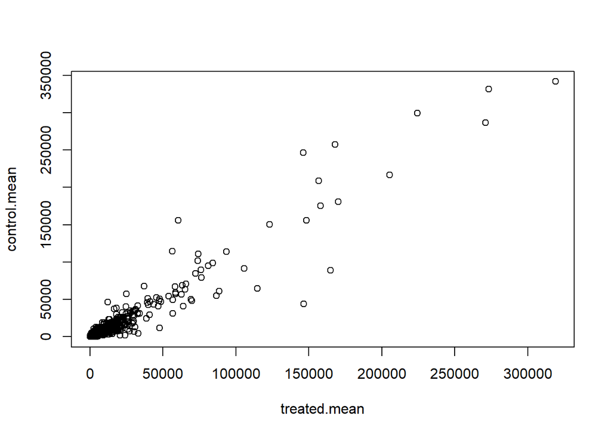

```r
#Summarize & visualize extracted data
control.mean <- rowMeans(control.counts)
treated.mean <- rowMeans(treated.counts)

plot(treated.mean, control.mean) #Q5
```

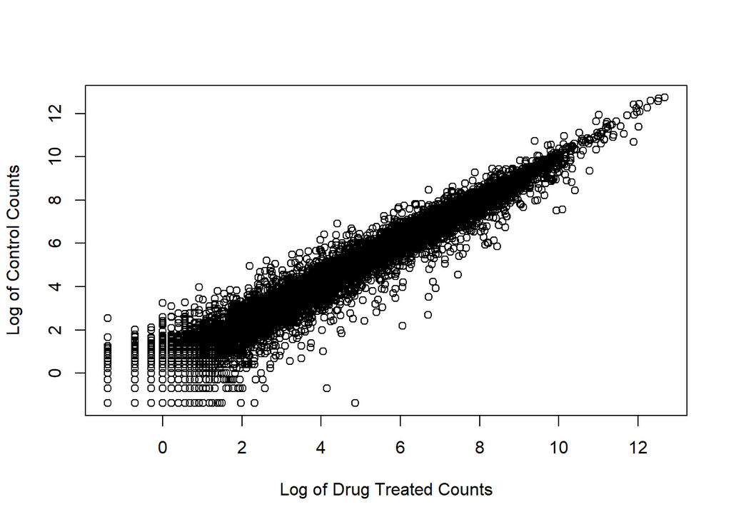

```r
plot(log(treated.mean), log(control.mean), #Q6
     xlab= "Log of Drug Treated Counts",
     ylab= "Log of Control Counts")
```

```r
#ggplot function: scale_x_continuous(trans="log2")
```

```r
#Calculate fold change between treated and untreated patients
#log2 of the fold change has better mathematical properties
treated.fold <- log2(treated.mean/control.mean)

#Organize Data
workingtable <- data.frame(control.mean, treated.mean, treated.fold)

#Remove Nonsensical Data
zero.vals <- which(workingtable[,1:2]==0, arr.ind=TRUE)

to.rm <- unique(zero.vals[,1])
workingtable2 <- workingtable[-to.rm,]
head(workingtable2)
```

|  | control.mean | treated.mean | treated.fold |
| --- | --- | --- | --- |
| ENSG00000000003 | 900.75 | 658.00 | -0.45303916 |
| ENSG00000000419 | 520.50 | 546.00 | 0.06900279 |
| ENSG00000000457 | 339.75 | 316.50 | -0.10226805 |
| ENSG00000000460 | 97.25 | 78.75 | -0.30441833 |
| ENSG00000000971 | 5219.00 | 6687.50 | 0.35769358 |
| ENSG00000001036 | 2327.00 | 1785.75 | -0.38194109 |

#Q7. The purpose of the arr.ind is to make the output of the which() function into a table specifying the row and column of where the result is found, rather than a list that doesn’t apply well onto a table. We would then need to call the unique() function to ensure that we don’t delete two separate rows for an instance where both the before and after values are 0.

```r
#Find up-regulated & down-regulated genes
up.ind <- workingtable2$treated.fold > (2)
down.ind <- workingtable2$treated.fold < (-2)

#Determine number of up-regulated and down-regulated genes
sum(up.ind) #Q8
```

```
## [1] 250
```

```r
sum(down.ind) #Q9
```

```
## [1] 367
```

#Q8. There are 250 up-regulated genes.

#Q9. There are 367 donw-regulated genes.

#Q10. These results are good, but they need to be determined whether or not they are actually statistically significant. The mean is also a single-number summary that can hide a lot of detail within itself.

## DESeq2 Analysis

```r
#Format data into input for DESeq2
dds <- DESeqDataSetFromMatrix(countData=counts,
                              colData=metadata,
                              design=~dex)
dds
```

```
## class: DESeqDataSet
## dim: 38694 8
## metadata(1): version
## assays(1): counts
## rownames(38694): ENSG00000000003 ENSG00000000005 ... ENSG00000283120
##   ENSG00000283123
## rowData names(0):
## colnames(8): SRR1039508 SRR1039509 ... SRR1039520 SRR1039521
## colData names(4): id dex celltype geo_id
```

```r
#Run the program to get p-values
dds <- DESeq(dds)
#View results
res <- results(dds)
head(res)
```

```
## log2 fold change (MLE): dex treated vs control
## Wald test p-value: dex treated vs control
## DataFrame with 6 rows and 6 columns
##                   baseMean log2FoldChange     lfcSE      stat    pvalue
##                  <numeric>      <numeric> <numeric> <numeric> <numeric>
## ENSG00000000003 747.194195     -0.3507030  0.168246 -2.084470 0.0371175
## ENSG00000000005   0.000000             NA        NA        NA        NA
## ENSG00000000419 520.134160      0.2061078  0.101059  2.039475 0.0414026
## ENSG00000000457 322.664844      0.0245269  0.145145  0.168982 0.8658106
## ENSG00000000460  87.682625     -0.1471420  0.257007 -0.572521 0.5669691
## ENSG00000000938   0.319167     -1.7322890  3.493601 -0.495846 0.6200029
##                      padj
##                 <numeric>
## ENSG00000000003  0.163035
## ENSG00000000005        NA
## ENSG00000000419  0.176032
## ENSG00000000457  0.961694
## ENSG00000000460  0.815849
## ENSG00000000938        NA
```

## Volcano Plots

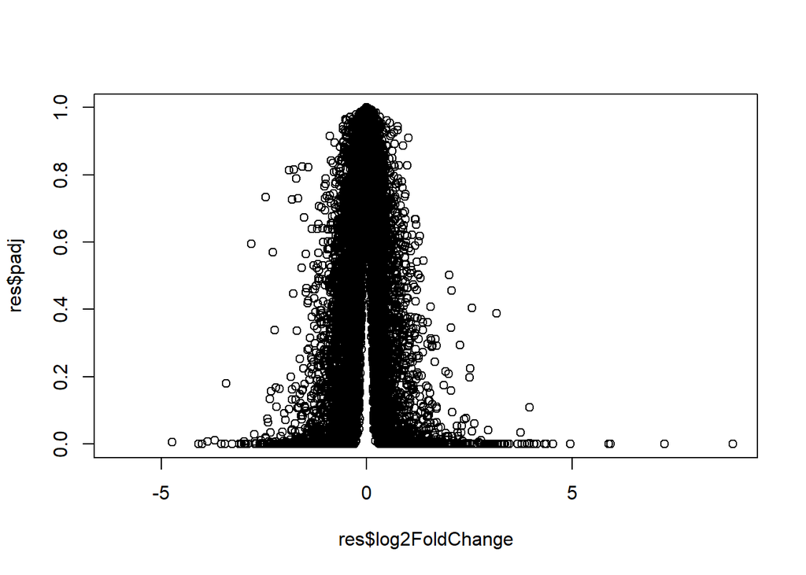

```r
#Raw DESeq2 output plot
plot(res$log2FoldChange,res$padj)
```

```r
#Make custom color vector for plot

##Make vector with default color, same length as the number of plotted pts
custom.color <- rep("gray", nrow(res))

##Overwrite high fold change points with red
custom.color[abs(res$log2FoldChange) > 2] <- "red"

##Overwrite points with high p-value with blue
custom.color[(res$padj < 0.05) & (abs(res$log2FoldChange) > 2)] <- "blue"
###High p-value = small -log(padj), since the negative of the log will flip these paints from near zero to large positive numbers
```

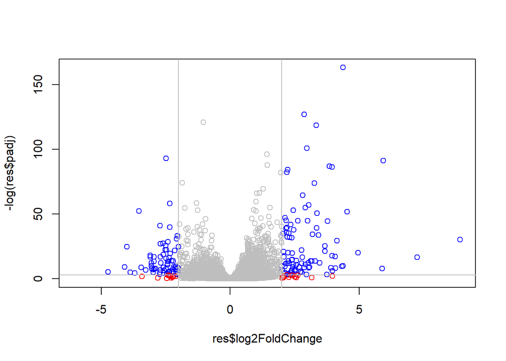

```r
#Log DESeq2 output plot & annotate by color
plot(res$log2FoldChange,-log(res$padj),
     col=custom.color)
abline(h=-log(0.05), col="gray")
abline(v=c(-2,2), col="gray")
```

## Adding annotation data - equivalent to looking up all the genes in a database manually, but automated!

To help interpret our results we need to understand what the differentially expressed genes are. A first step here is to get the gene names (i.e. gene SYMBOLs).

For this I will install: - BiocManager::install(“AnnotationDbi”) - BiocManager::install(org.Hs.eg.db”)

We will use the `mapIds()` function to translate between different ids.

```r
#All available types to map between: `columns(org.Hs.eg.db)`
library(AnnotationDbi)
library(org.Hs.eg.db)
res$symbol <- mapIds(org.Hs.eg.db,
                     keys=row.names(res), # Our genenames
                     keytype="ENSEMBL",        # The format of our genenames
                     column="SYMBOL",          # The new format we want to add
                     multiVals="first")
head(res)
```

```
## log2 fold change (MLE): dex treated vs control
## Wald test p-value: dex treated vs control
## DataFrame with 6 rows and 7 columns
##                   baseMean log2FoldChange     lfcSE      stat    pvalue
##                  <numeric>      <numeric> <numeric> <numeric> <numeric>
## ENSG00000000003 747.194195     -0.3507030  0.168246 -2.084470 0.0371175
## ENSG00000000005   0.000000             NA        NA        NA        NA
## ENSG00000000419 520.134160      0.2061078  0.101059  2.039475 0.0414026
## ENSG00000000457 322.664844      0.0245269  0.145145  0.168982 0.8658106
## ENSG00000000460  87.682625     -0.1471420  0.257007 -0.572521 0.5669691
## ENSG00000000938   0.319167     -1.7322890  3.493601 -0.495846 0.6200029
##                      padj      symbol
##                 <numeric> <character>
## ENSG00000000003  0.163035      TSPAN6
## ENSG00000000005        NA        TNMD
## ENSG00000000419  0.176032        DPM1
## ENSG00000000457  0.961694       SCYL3
## ENSG00000000460  0.815849    C1orf112
## ENSG00000000938        NA         FGR
```

#Q11. Run the mapIds() function two more times to add the Entrez ID and UniProt accession and GENENAME as new columns called res$entrez, res$uniprot and res$genename.

```r
#Entrez ID column
res$entrez <- mapIds(org.Hs.eg.db,
                     keys=row.names(res),
                     keytype="ENSEMBL",
                     column="ENTREZID",
                     multiVals="first")
#UniProt Accession Number
res$uniprot <- mapIds(org.Hs.eg.db,
                      keys=row.names(res),
                      keytype="ENSEMBL",
                      column="UNIPROT",
                      multiVals="first")
#Gene Name
res$genename <- mapIds(org.Hs.eg.db,
                      keys=row.names(res),
                      keytype="ENSEMBL",
                      column="GENENAME",
                      multiVals="first")
```